# Internet Gambling Behavior Study

Open Source Programming Group Assignment - Group 8

Remy Doyen, Saeed , Paulina Valencia

## Abstract

Online gambling (or Internet gambling) includes poker, casinos and sports betting. Gambling has become one of the most popular and lucrative businesses present on the Internet. This also means that there has been an increase in online gambling addiction, hence there is a big danger concerning gamblers:

- One in five online gamblers may be pathological gamblers
- Approximately 4% of teenagers have a gambling problem.
- There are no official product safety standards and regulations for online casinos. Players who choose to wager at online gambling websites essentially do so at their own risk.

This study will analyze data from internet gambling and has two main objectives:

- Get to know the user’s characteristics and demographics to have a deeper understanding of who the customers are.
- Analyze factors that can influence both user’s and business owner’s profit in order to make better decisions in the future.

To do so, we gathered information about user’s demographics, betting information, poker chip transactions and betting behavior. Then we calculated some useful metrics such as user duration, active days, bets per day, etc.

There are 4 main activities that are being analyzed in this study:

- Fixed Odds Sports: the traditional form of betting where a bookmaker will offer odds on a specific outcome in a match or event.
- Live Action Sports: defined as the act of placing wagers on an event, match, or race while it is still in progress.
- Poker: a family of card games that combines gambling, strategy, and skill.
- Other: this includes Casino BossMedia, Supertoto, Games VS, Games bwin and Casino Chartwell.

## Preparation of database

### Package Installation

In this study we used the following packages:

- **dplyr**: dplyr is a powerful R-package to transform and summarize tabular data with rows and columns
- **ggplot2**: is a system for ‘declaratively’ creating graphics, based on “The Grammar of Graphics”.
- **haven**: haven is used to import and export SPSS, Stata and SAS Files
- **plyr**: is a package that provides a set of tools for data manipulation.
- **shiny**: shiny is used to build interactive web applications with R.
- **shinythemes**: shinythemes is used to load a specific theme into the App.
- **shinyWidgets**: shinyWidgets provides some custom inputs widgets to use in Shiny applications.

For the installation and loading of each package we used the command:

`if(!require("dplyr")) install.packages("dplyr"); library("dplyr")`

### Loading and grouping the data

The data was given in *SAS data set format*, so we used the function *read_sas*:

```r
data <- read_sas("AnalyticDataInternetGambling.sas7bdat")
```

```r
# Splitting activity into sport / other
BetSport <- sum(raw2$ProductID == 1 | raw2$ProductID == 2)
BetOther <- sum(raw2$ProductID == 4 | raw2$ProductID == 5 | raw2$ProductID == 6 | raw2$ProductID == 7 | raw2$ProductID == 8) + length(unique(raw3$UserID))
PercentageBetSport <- BetSport/(BetSport+BetOther)
print(PercentageBetSport)
```

```
## [1] 0.9558213
```

Since 95% of the gambling activity are sport bets, we decided to do two groups:

- Sports (Fixed odds and Live Action)
- Other (all the other types of gambling)

Sports then is also divided into 2 categories:

- Fixed Odds Sports
- Live Action Sports

For the grouping of the data we decided to use the function *ddply* which for each subset of a data frame, it will use the apply function then combine results into a data frame. We applied this function with the objective of aggregating the data and getting tables with 1 user per row. The following tables were used:

- *User Daily Aggregation* table. We grouped data by adding numeric variables like *stakes* and *winnings* and counting number of users to get the frequency. In this table we also divided data based on activities (*sports* and *other*) as mentioned before.
- *Poker Chip Conversions* table. We grouped data by adding numeric variables like *transaction amount* and splitting into *buy* or *sell* and counting number of users to get the frequency. We also created a nrew column *buysell* which calculates the net win/loss per user.

### Merging into one basetable

Once we grouped all the tables and obtained unique values for users, the next step is merging. The key table used for merging was *Demographics* because it contains unique information about the 42,649 Users that are analyzing. The final result was a basetable with 42,649 rows and 44 variables.

Since the original demographics table contained numeric values for the variables: country, language and application ID, we changed these columns in order to have the actual names. This was made by merging with 3 tables containing the relevant information about this variables.

```r
#Merging all data together by UserID
all_data<-merge(x=c_raw1, y=c_data,by="UserID",all.x=TRUE)
all_data<-merge(x=all_data, y=raw2_all,by="UserID",all.x=TRUE)
all_data<-merge(x=all_data, y=raw3_groupedAll,by="UserID",all.x=TRUE)
all_data<-merge(x=all_data, y=Poker_buy_grouped,by="UserID",all.x=TRUE)
all_data<-merge(x=all_data, y=other_groupedAll,by="UserID",all.x=TRUE)
```

## Creation of metrics

We created metrics in order to have insights about the users with the objective of representing them visually. This way it is easier to draw conclusions. The selected metrics will be discussed in further detail.

### Profit

Profit is a financial benefit that is realized when the amount of revenue gained from a business activity exceeds the expenses, costs and taxes needed to sustain the activity. So in this research profit refers to the difference between amount of money that the customers won through betting and the money that they spend in the business. Obviously, the minus profit refers to loss.

```r
#Profit
all_data$FO_Profit <- all_data$FOTotalWinnings-all_data$FOTotalStakes
all_data$LA_Profit <- all_data$LATotalWinnings-all_data$LATotalStakes
all_data$Profit_Sport <- all_data$Sport_winnings-all_data$Sports_stakes
all_data$Profit_Other <- all_data$Other_winnings-all_data$Other_stakes
all_data$Poker_Profit<-all_data$Poker_Profit #This variable was created when grouping
```

### Duration

Duration has been calculated based on the number of days from the first eligible bet to the last one.

```r
all_data$FO_Duration <- as.numeric(all_data$FOLastActiveDate-all_data$FOFirstActiveDate)+1
all_data$LA_Duration <- as.numeric(all_data$LALastActiveDate-all_data$LAFirstActiveDate)+1
all_data$Poker_Duration <- as.numeric(all_data$Poker_Duration) #This variable was created when grouping
all_data$Other_Duration<-as.numeric(all_data$Other_Duration) #This variable was created when grouping
all_data$Sport_Duration <- ifelse(is.na(all_data$FO_Duration) & is.na(all_data$LA_Duration),NA,
                                   ifelse(is.na(all_data$FO_Duration),all_data$LA_Duration,
                                          ifelse(is.na(all_data$LA_Duration),all_data$FO_Duration,                                                        ifelse(all_data$FO_Duration>=all_data$LA_Duration,all_data$FO_Duration,all_data$LA_Duration))))
```

### Activity

The term refers to the result of “number of Active days” divided to the “Duration”.

```r
all_data$FO_Activity <- all_data$FOTotalDaysActive/all_data$FO_Duration
all_data$LA_Activity <- all_data$LATotalDaysActive/all_data$LA_Duration
all_data$Sport_Activity<- ifelse(is.na(all_data$FOTotalDaysActive) & is.na(all_data$LATotalDaysActive),NA,
                                  ifelse(is.na(all_data$FOTotalDaysActive),all_data$LATotalDaysActive,
                                         ifelse(is.na(all_data$LATotalDaysActive),all_data$FOTotalDaysActive,                                                ifelse(all_data$FOTotalDaysActive>=all_data$LATotalDaysActive,all_data$FOTotalDaysActive,all_data$LATotalDaysActive))))/all_data$Sport_Duration
all_data$Poker_Activity <- all_data$PokerTotalDayActive/all_data$Poker_Duration
all_data$Other_Activity <- all_data$OtherTotalDayActive/all_data$Other_Duration
```

### Bets per Day

This explains the average of the number of bets that have been done per each single day. For *Poker* and *Other* this calculation was not possible due to the way these games are played.

```r
all_data$FO_BetPerDay <- all_data$FOTotalBets/all_data$FO_Duration
all_data$LA_BetPerDay <- all_data$LATotalBets/all_data$LA_Duration
all_data$Sport_BetPerDay <- (all_data$FOTotalBets+all_data$LATotalBets)/all_data$Sport_Duration
```

### Euro per Bet

This term represents the average of amount of money (Euro) that has been spent by each customer during his/her active days. For *Poker* and *Other* this calculation was not possible due to the way these games are played.

```r
all_data$FO_EuroPerBet <- all_data$FOTotalStakes/all_data$FOTotalBets
all_data$LA_EuroPerBet <- all_data$LATotalStakes/all_data$LATotalBets
all_data$Sport_EuroPerBet <- all_data$Sports_stakes/(all_data$FOTotalBets+all_data$LATotalBets)
```

### Return of Investment (ROI)

ROI tries to directly measure the amount of return on an particular investment, relative to the investment’s cost. This study used ROI to calculate the benefit of betting (profit) divided by the cost of the investment (stake).

```r
all_data$FO_ROI <- all_data$FO_Profit/all_data$FOTotalStakes
all_data$LA_ROI <- all_data$LA_Profit/all_data$LATotalStakes
all_data$Sport_ROI <- all_data$Profit_Sport/all_data$Sports_stakes
all_data$Poker_ROI <- all_data$Poker_Profit/all_data$Poker_Stakes
all_data$Other_ROI <- all_data$Profit_Other/all_data$Other_stakes
```

The final step on the creation of the basetable was to reorder the variables to faciliate the reading and to remove unused variables like language code and country code. We also changed gender to *male* and *female* instead of 1 and 0. The creation of dummy variables was needed in order to count the number of users participating in each activity (*sports, LA, FO, Poker, Other*).

**It is important to note that one user can participate in more than one activity**

```r
basetable<-all_data[,c(1,9,13,15:17,20:23,26,28:30,32:34,36:68)]
#Order
basetable<-basetable[,c(1,2,3,24,25,26,12,13,14,29,31,34,37,42,45,48,4,5,6,7,27,32,35,40,43,46,8,9,10,11,28,33,36,41,44,47,18,19,20,21,38,49,15,16,17,22,23,30,39,50)]
#Fixing
basetable$Gender<-ifelse(basetable$Gender==1, "Male", "Female")
#Create Dummy variables
basetable$Sport_Dummy<-ifelse(is.na(basetable$Sports_stakes)==1,0,1)
basetable$LA_Dummy<-ifelse(is.na(basetable$LATotalStakes)==1,0,1)
basetable$FO_Dummy<-ifelse(is.na(basetable$FOTotalStakes)==1,0,1)
basetable$Poker_Dummy<-ifelse(is.na(basetable$Poker_Stakes)==1,0,1)
basetable$Other_Dummy<-ifelse(is.na(basetable$Other_stakes)==1,0,1)
basetable$Gender<-as.factor(basetable$Gender)
```

This concludes the creation of the basetable. The final outcome was a table with 42,649 rows and 55 variables.

## Creation of Shiny App

In order to use the demographic data and the metrics that we have just created, we built a Shiny Application. This app contains trhee differents tabs:

- Customer Information
- Market Insights
- More Insights

### Tab 1: Customer Information

The first tab of the Shiny App use several descriptive variables (age, gender, country) and allows us to understand who the customers are. It contains several filters. Indeed, the final user is able to choose one or several countries, the gender of the gamblers and the application used to access to Bwin.

After choosing the different parameters, two graphs and one table will be displayed. The first graph shows a histogram of the repartition of the gamblers’ age. Here is an example for France, considering both male and female and all the possible application.

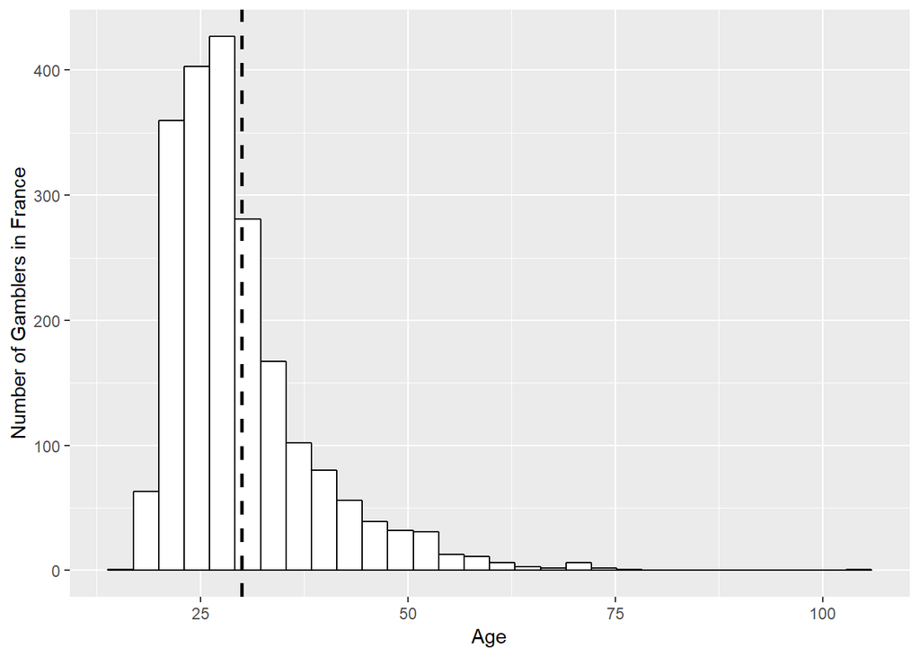

On the second graph, we can observ the number of gamblers according to the games played. Here are the results using the sa me example as before:

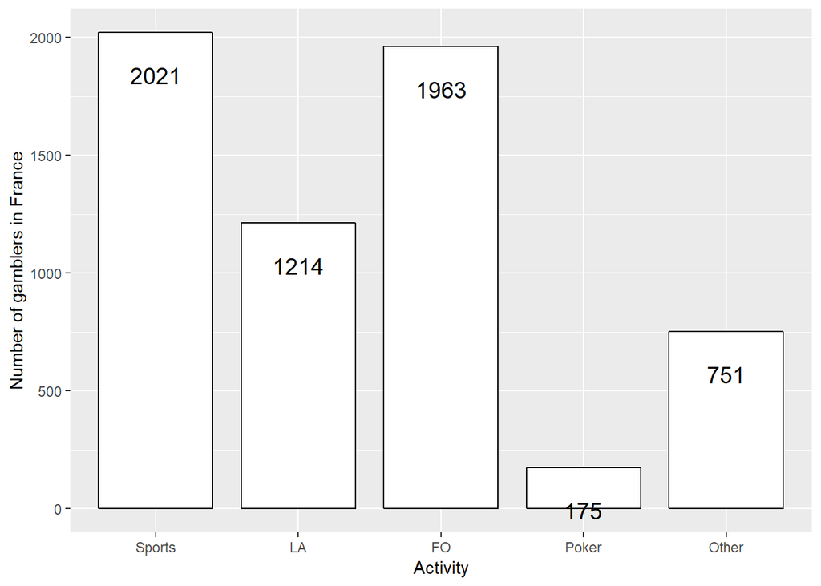

Finally, the last thing on this panel is a table containing several descriptive statistics about the age:

```
##   Count Mean Age Median Age Min Age Max Age St.Dev Age
## 1  2087 29.97173         28      16     105   8.690903
```

### Tab 2: Market Insights

The second tab is used to understand, for each category of activity, what is the relationship between the profit of the other metrics created.

The idea is to understand which kind of gambler has the most risk to lose money so that the appropriate actions can be taken concerning these gamblers.

This tab contains 5 graphs (one for each category of activity). For each of these graphs, the final users is able to select which metric he wants to compare with the profit.

For instance, here below, is the graph showing the relationship between the profit of the users and their total stakes, for the Fixed Odds bets:

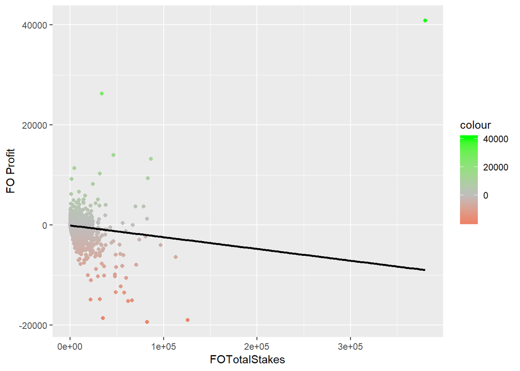

### Tab 3: More Insights

For the creation of the 3rd tab: *More Insights* we decided to add a scatter graph. We decided to leave the axes as variable so that it could be easier to *play* with the metrics and compare them. This tab is more flexible and therefore there will be some combinations of variables that when plotted will not make any sense. However, there are also interesting insights when comparing variables belonging to the same category (sport’s profit vs sport’s stakes)

## Conclusion and Recommendations

To conclude this study we analyzed the results of our calculated metrics and their visual representations and came up with some useful insights.

By analyzing the number of gamblers based on the gender and age we can conclude that:

- 92% of the customers are male and about 80% (Mean+ SD ,mean = 31+ SD =10)of them are less than 41 years old that should be considered for segmenting market.
- More than of 70% of men (almost 65% of all customers) spent money at least once on either ’’Sports" or “Fixed odd”
- Furthermore, “LA” with 22% ,other games, and Poker with 5 and 2 percent respectively are less popular games.
- More than half of the female customers are less than 35 and the trends also shows the same popularity of “sport” and “Fixed odd” for this group of customers.
- The trends shows that less than 3 percent of our customers are more than 51.(mean+2sd = 51 years old)

By analyzing general trends of the Return of Investment (ROI) rate for different types of games, we can see that this rate shows a positive trend for categories like *Sports*, *Fixed Odds*, and *Poker* but it presents negative trend for *Other* game classification.

The trend lines in the scatter plots created in tab 2 of the shiny app show that the relation between *stakes* and *profit* is positive only in poker games. This means that in other types of betting the profit will decrease sharply if customer bets more amount of money so it can be proposed to customers who want to bet more than 100k euros to play poker instead of other types of games.

By analyzing the duration and activity of users, we discover that there is no relation between the profit and the duration or customers’ activity .

As mentioned at the first paragraph, more than 80 percent of our customers are less than 41 and analyzing trends shows that this age group bet more money and the ROI trends shows more positive trend than those who are more than 41. It may root to this matter that younger people usually show more risk taking behaviors and they are more optimistic to bet large amount of money in different type of betting. Having said that, it can be a good strategy for company to spend more time and efforts to preserve this age group of customers because at the end they will make more profit for the company as well.